# Quickstart

## Import plotly_light

```python
import plotly_light as pl
```

```
[I 250423 19:54:27 __init__:46] plotly_light: in Jupyter
```

```
[I 250423 19:54:27 __init__:62] pl.default.renderer = iframe_connected
```

**NOTE:** If imported in a Jupyter Notebook, `init_notebook_mode(connected=True)` is automatically run.

**NOTE:** If running in a Jupyter Notebook, each plot is by default stored as an HTML file in a directory named `iframe_figures/` and embedded to the Notebook using `<iframe>`. Here we change the renderer to `notebook` so that this file can be downloaded as an HTML file with plots.

```python
pl.set_default_renderer("notebook_connected")
```

## Usage example: Drawing a simple histogram in a Jupyter Notebook

```python
import random
data = random.choices(list(range(10)), k=10000)
```

### The simplest (and lightweight) histogram

The code below draws a histgram of many random numbers. You can confirm the file size of the plot do not increase even with a very large `k`, i.e. the number of data. With the original Plotly, the file size increases in proportion to the data size.

```python
trace = pl.hist(data, bin_size=1)
pl.show(trace)
```

[interactive chart not shown]

### Add a legend

By default, the legend is hidden. You can show it with arbitrary name of the histogram:

```python
trace = pl.hist(data, bin_size=1, name="Random", show_legend=True)
pl.show(trace)
```

[interactive chart not shown]

### Customize the layout

```python
layout = pl.layout(width=500, height=300, x_title="Number", y_title="Frequency", x_dtick=1,
                   legend_horizontal=True, legend_coord=(0.05, 1.2))
pl.show(trace, layout)
```

[interactive chart not shown]

# Plots

## `pl.hist`: Histogram

Lightweight histogram using a `go.Bar` instead of `go.Histogram`.

```python
pl.show(pl.hist([1, 2, 3], bin_size=1))
```

[interactive chart not shown]

**NOTE:** Specifying `bin_size` (and `start` and `end` as well) will result in a natural binning.

You can force to use `go.Histogram`:

```python
pl.show(pl.hist([1, 2, 3], bin_size=1, use_histogram=True))
```

[interactive chart not shown]

## `pl.bar`: Bar plot

Wrapper for `go.Bar`.

```python
pl.show(pl.bar([1, 2], [3, 4]))
```

[interactive chart not shown]

## `pl.scatter`: Scatter plot

Wrapper for `go.Scatter`.

```python
pl.show(pl.scatter([1, 2], [3, 4]))
```

[interactive chart not shown]

## `pl.box`: Box plot

Wrapper for `go.Box`.

```python
pl.show(pl.box([1, 2, 3], name="data", show_points=True))
```

[interactive chart not shown]

## `pl.violin`: Violin plot

Wrapper for `go.Violin`.

```python
pl.show(pl.violin([1, 2, 3], name="data", show_points=True))
```

[interactive chart not shown]

## `pl.lines`: Line(s)

Scatter plot trace with line(s).

```python
pl.show(pl.lines([(1, 0, 2, 1), (1, 1, 2, 0)]))
```

[interactive chart not shown]

You can make shape objects as well:

```python
pl.show(None, pl.layout(shapes=pl.lines_shape([(1, 0, 2, 1), (1, 1, 2, 0)])))
```

[interactive chart not shown]

## `pl.rect`: Rectangle(s)

Utility for generating a rectangle shape object.

```python
pl.show(pl.rects([(0, 0, 1, 1), (2, 2, 3, 3)]))
```

[interactive chart not shown]

You can make shape objects as well:

```python
pl.show(None, pl.layout(shapes=pl.rects_shape([(0, 0, 1, 1), (2, 2, 3, 3)])))
```

[interactive chart not shown]

## `pl.venn`: Venn diagram

Venn diagram using `matplotlib-venn` (not a Trace nor Figure object).

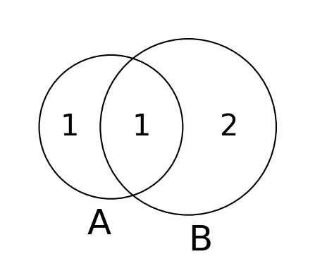

```python
pl.venn([[1, 2], [2, 3, 4]], ["A", "B"], out_fname="venn.png")
```

## `pl.image`: Plot an image file

```python
pl.image("venn.png")
```

[interactive chart not shown]

# Functions for configuration

## `pl.update_default_layout`: Change the defalt layout

Plotly Light's default layout is tuned based on the original Plotly's `simple_white` theme. It is stored in the variable `pl.default.layout` as a dict:

```python
pl.default.layout
```

```
{'width': 500,
 'height': 500,
 'annotationdefaults': {'arrowhead': 0, 'arrowwidth': 1},
 'autotypenumbers': 'strict',
 'coloraxis': {'colorbar': {'outlinewidth': 1,
   'tickcolor': 'lightgray',
   'ticks': ''}},
 'colorscale': {'diverging': [[0.0, 'rgb(103,0,31)'],
   [0.1, 'rgb(178,24,43)'],
   [0.2, 'rgb(214,96,77)'],
   [0.3, 'rgb(244,165,130)'],
   [0.4, 'rgb(253,219,199)'],
   [0.5, 'rgb(247,247,247)'],
   [0.6, 'rgb(209,229,240)'],
   [0.7, 'rgb(146,197,222)'],
   [0.8, 'rgb(67,147,195)'],
   [0.9, 'rgb(33,102,172)'],
   [1.0, 'rgb(5,48,97)']],
  'sequential': [[0.0, '#440154'],
   [0.1111111111111111, '#482878'],
   [0.2222222222222222, '#3e4989'],
   [0.3333333333333333, '#31688e'],
   [0.4444444444444444, '#26828e'],
   [0.5555555555555556, '#1f9e89'],
   [0.6666666666666666, '#35b779'],
   [0.7777777777777778, '#6ece58'],
   [0.8888888888888888, '#b5de2b'],
   [1.0, '#fde725']],
  'sequentialminus': [[0.0, '#440154'],
   [0.1111111111111111, '#482878'],
   [0.2222222222222222, '#3e4989'],
   [0.3333333333333333, '#31688e'],
   [0.4444444444444444, '#26828e'],
   [0.5555555555555556, '#1f9e89'],
   [0.6666666666666666, '#35b779'],
   [0.7777777777777778, '#6ece58'],
   [0.8888888888888888, '#b5de2b'],
   [1.0, '#fde725']]},
 'colorway': ['#0b8bee',
  '#ffcd00',
```

[output cut: 98 more lines]

```
   'linecolor': 'black',
   'showgrid': False,
   'showline': True,
   'ticks': ''},
  'baxis': {'gridcolor': 'rgb(232,232,232)',
   'linecolor': 'black',
   'showgrid': False,
   'showline': False,
   'ticks': ''},
  'bgcolor': 'white',
  'caxis': {'gridcolor': 'rgb(232,232,232)',
   'linecolor': 'black',
   'showgrid': False,
   'showline': False,
   'ticks': ''}}}
```

You can update the default layout with a layout object. For example, the following code changes the default font size and margin size:

```python
pl.update_default_layout(pl.layout(font_size=40, margin=dict(l=10, r=10, t=100, b=10)))
```

Or you can replace the default layout:

```python
pl.set_default_layout(...)
```

Or you can permanently change the default layout by modifying the `src/default.py` file and re-installing plotly_light.

### `pl.set_default_colors`: Change only the color set

If you want to change only the default color set, you can use:

```python
pl.set_default_colors?
```

```
Signature: pl.set_default_colors(cols: List[str]) -> None
Docstring: <no docstring>
File:      ~/.local/lib/python3.13/site-packages/plotly_light/_config.py
Type:      function
```

### `pl.set_default_theme`: Change the default theme

To change the default theme, use the following function:

```python
pl.set_default_theme?
```

```
Signature: pl.set_default_theme(theme_name: str, keep_layout: bool = True) -> None
Docstring:
Change plotly's default theme.

positional_arguments:
  @ theme_name : A plotly theme name. Must be one of:
                  {"plotly_light",   (default)
                   "ggplot2",
                   "seaborn",
                   "simple_white",
                   "plotly",
                   "plotly_white",
                   "plotly_dark",
                   "none"}

optional arguments:
  @ keep_layout : If True, overwrite the theme's layout with the
                         default layout set by `set_default_layout()`.
File:      ~/.local/lib/python3.13/site-packages/plotly_light/_config.py
Type:      function
```

## `pl.update_default_config`: Change the default config

The default config is managed in the same manner as the default layout. The `pl.default.config` variable is a dict:

```python
pl.default.config
```

```
{'showTips': False,
 'displaylogo': False,
 'modeBarButtonsToAdd': ['hoverclosest', 'hovercompare'],
 'toImageButtonOptions': {'format': 'svg'},
 'responsive': True}
```

And you can update it with a dict:

```python
pl.update_default_config({'toImageButtonOptions': {'format': 'png'}})
```

Or you can replace it:

```python
pl.set_default_config(...)
```

Or you can permanently change the default config by modifying the `src/default.py` file and re-installing plotly_light.

## `pl.set_default_renderer`: Change the default renderer

The renderer is automatically determined based on the environment in which plotly_light is imported. The name of the current renderer is stored in the `pl.default.renderer` as a str:

```python
pl.default.renderer
```

[output not shown]

If imported in Jupyter Notebook, then normally the default renderer should be `iframe` where each plot is saved as an HTML file and embedded to the Notebook with `<iframe>`. You can explicitly change a different renderer with:

```python
pl.set_default_renderer("plotly_mimetype+notebook_connected")
```

The list of the availble renderers is written in the docstring of `pl.set_default_renderer`:

```python
pl.set_default_renderer?
```

```
Signature: pl.set_default_renderer(renderer_name: str) -> None
Docstring:
Change plotly's default renderer.

positional_arguments:
  @ renderer_name : A plotly theme name:
                      - "plotly_mimetype" (NBclassic)
                      - "browser" (default browser)
                      - "notebook[_connected]" (NBclassic)
                      - "iframe[_connected]" (embed as iframe)
                      - "jupyterlab" (JupyterLab)
                      - "png" / "svg" / "pdf" (static image)
File:      ~/.local/lib/python3.13/site-packages/plotly_light/_config.py
Type:      function
```